# Logical S Gate

## Construction

The S gate is teleported in two steps:

- an $M_{ZZ}$ measurement between the target qubit and an ancilla qubit initialized in the $|+\rangle$ state,
- a Y basis measurement of the ancilla qubit, done by a Y half cube.

`tqec` provides the builtin function `tqec.gallery.s_gate_teleportation` to construct it. The `In` port is at the bottom of the block graph and the `Out` port is at the top.

```python
%matplotlib inline
```

```python
# ruff: noqa: E402

from tqec import PauliBasis
from tqec.gallery import s_gate_teleportation

graph = s_gate_teleportation(PauliBasis.X)
```

```python
graph.view_as_html()
```

[interactive chart not shown]

```python
correlation_surfaces = graph.find_correlation_surfaces()
```

```python
graph.view_as_html(
    pop_faces_at_directions=("-Y",),
    show_correlation_surface=correlation_surfaces[0],
)
```

[interactive chart not shown]

## Circuit

You can download the circuit for a `d=3` S gate from :download:`here <../media/gallery/s_gate/circuit.stim>`, or generate it with the code below. The link it prints opens the `d=5` (`k=2`) circuit in Crumble.

```python
from IPython.display import HTML

from tqec import NoiseModel, compile_block_graph

compiled_graph = compile_block_graph(graph)
circuit = compiled_graph.generate_stim_circuit(
    k=1, noise_model=NoiseModel.uniform_depolarizing(p=0.001)
)
HTML(f'<a href="{compiled_graph.generate_crumble_url(k=2)}">Open the d=5 circuit in Crumble</a>')
```

Open the d=5 circuit in Crumble

## Simulation

Here we show the simulation results of the $X \rightarrow Y$ and $Z \rightarrow Z$ flows under the **uniform depolarizing** noise model.

The full code used for the simulation is shown below.

```python
from multiprocessing import cpu_count
from pathlib import Path

import matplotlib.pyplot as plt
import numpy
import sinter

from tqec.simulation.plotting.inset import plot_observable_as_inset
from tqec.simulation.simulation import start_simulation_using_sinter


def generate_graphs(in_observable_basis: PauliBasis) -> None:
    """Generate the logical error-rate graphs corresponding to the provided basis."""
    block_graph = s_gate_teleportation(in_observable_basis)
    zx_graph = block_graph.to_zx_graph()

    correlation_surfaces = block_graph.find_correlation_surfaces()

    stats = start_simulation_using_sinter(
        block_graph,
        range(1, 4),
        list(numpy.logspace(-4, -1, 10)),
        NoiseModel.uniform_depolarizing,
        manhattan_radius=2,
        observables=correlation_surfaces,
        num_workers=cpu_count(),
        max_shots=1_000_000,
        max_errors=5_000,
        decoders=["pymatching"],
        # note that save_resume_filepath and database_path can help reduce the time taken
        # by the simulation after the database and result statistics have been saved to
        # the chosen path
        save_resume_filepath=Path(
            f"../_examples_database/s_gate_stats_{in_observable_basis.value}.csv"
        ),
        database_path=Path("../_examples_database/database.pkl"),
    )

    for i, stat in enumerate(stats):
        _, ax = plt.subplots()
        sinter.plot_error_rate(
            ax=ax,
            stats=stat,
            x_func=lambda stat: stat.json_metadata["p"],
            failure_units_per_shot_func=lambda stat: stat.json_metadata["d"],
            group_func=lambda stat: stat.json_metadata["d"],
        )
        plot_observable_as_inset(ax, zx_graph, correlation_surfaces[i])
        ax.grid(axis="both")
        ax.legend()
        ax.loglog()
        ax.set_title("Logical S Gate Error Rate")
        ax.set_xlabel("Physical Error Rate")
        ax.set_ylabel("Logical Error Rate")
```

### $X \rightarrow Y$

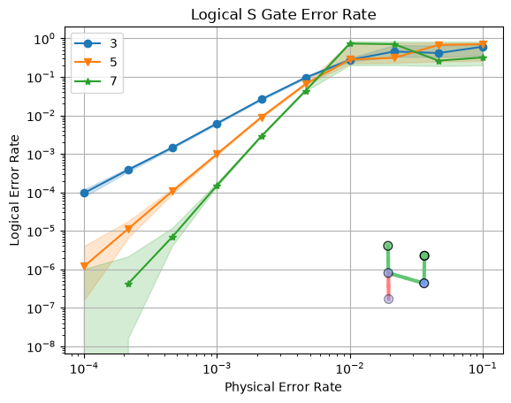

```python
generate_graphs(PauliBasis.X)
```

### $Z \rightarrow Z$

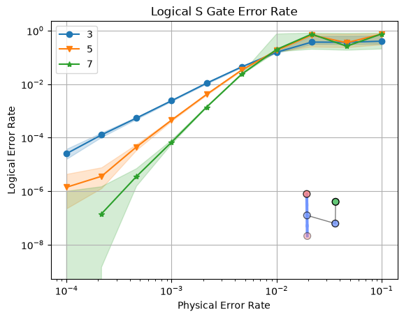

```python
generate_graphs(PauliBasis.Z)
```

## References

.. footbibliography::